# Artificial Intelligence Course - Fall 1402

## Computer Assignment #4 - Machine Learning

### provided by: Mohamad Amin Yousefi

#### SID: 810100236

## Imports

```python
import pandas as pd
import numpy as np
import matplotlib.pyplot as plt
import seaborn as sns
import math
from sklearn import metrics
from sklearn.model_selection import GridSearchCV
from sklearn.preprocessing import StandardScaler, MinMaxScaler
from sklearn.preprocessing import LabelEncoder
from sklearn.model_selection import train_test_split
from sklearn.tree import DecisionTreeClassifier, plot_tree
from sklearn.neighbors import KNeighborsClassifier
from sklearn.linear_model import LogisticRegression
from sklearn.ensemble import RandomForestClassifier
from xgboost import XGBClassifier
from mlxtend.evaluate import bias_variance_decomp
```

## Constants

```python
CSV_FILE = 'marketing_campaign.csv'
CORR_THRESHOLD = 0.2
```

## Dataset

Here we use a our dataset which contains data about the customers of a store and their amount of purchases in last two years.

```python
data = pd.read_csv(CSV_FILE)
pd.set_option("display.max_columns", None)
data.head(10)
```

|  | Unnamed: 0 | ID | Year_Birth | Education | Marital_Status | Income | Kidhome | Teenhome | Dt_Customer | Recency | MntCoffee | MntFruits | MntMeatProducts | MntFishProducts | MntSweetProducts | MntGoldProds | NumWebVisitsMonth | Complain | NumPurchases | UsedCampaignOffer |
| --- | --- | --- | --- | --- | --- | --- | --- | --- | --- | --- | --- | --- | --- | --- | --- | --- | --- | --- | --- | --- |
| 0 | 0 | 5524 | 1957 | Graduation | Single | 58138.0 | 0 | 0 | 04-09-2012 | 58 | 635.0 | 88 | 546 | 172 | 88 | 88.0 | NaN | 0 | 25 | 1 |
| 1 | 1 | 2174 | 1954 | Graduation | Single | 46344.0 | 1 | 1 | 08-03-2014 | 38 | NaN | 1 | 6 | 2 | 1 | 6.0 | 5.0 | 0 | 6 | 0 |
| 2 | 2 | 4141 | 1965 | Graduation | Together | 71613.0 | 0 | 0 | 21-08-2013 | 26 | NaN | 49 | 127 | 111 | 21 | 42.0 | NaN | 0 | 21 | 0 |
| 3 | 3 | 6182 | 1984 | Graduation | Together | 26646.0 | 1 | 0 | 10-02-2014 | 26 | 11.0 | 4 | 20 | 10 | 3 | 5.0 | 6.0 | 0 | 8 | 0 |
| 4 | 4 | 5324 | 1981 | PhD | Married | 58293.0 | 1 | 0 | 19-01-2014 | 94 | 173.0 | 43 | 118 | 46 | 27 | 15.0 | 5.0 | 0 | 19 | 0 |
| 5 | 5 | 7446 | 1967 | Master | Together | NaN | 0 | 1 | 09-09-2013 | 16 | 520.0 | 42 | 98 | 0 | 42 | 14.0 | NaN | 0 | 22 | 0 |
| 6 | 6 | 965 | 1971 | Graduation | Divorced | 55635.0 | 0 | 1 | 13-11-2012 | 34 | 235.0 | 65 | 164 | 50 | 49 | 27.0 | 6.0 | 0 | 21 | 0 |
| 7 | 7 | 6177 | 1985 | PhD | Married | 33454.0 | 1 | 0 | 08-05-2013 | 32 | 76.0 | 10 | 56 | 3 | 1 | 23.0 | 8.0 | 0 | 10 | 0 |
| 8 | 8 | 4855 | 1974 | PhD | Together | 30351.0 | 1 | 0 | 06-06-2013 | 19 | 14.0 | 0 | 24 | 3 | 3 | 2.0 | 9.0 | 0 | 6 | 1 |
| 9 | 9 | 5899 | 1950 | PhD | Together | 5648.0 | 1 | 1 | 13-03-2014 | 68 | 28.0 | 0 | 6 | 1 | 1 | 13.0 | 20.0 | 0 | 2 | 1 |

## Exploratory Data Analysis (EDA)

### Info and Describe methods

The `info` function provides comprehensive details regarding the dataframe, encompassing general information, data overview, and data type specifications.

```python
data.info()
```

```
<class 'pandas.core.frame.DataFrame'>
RangeIndex: 2240 entries, 0 to 2239
Data columns (total 20 columns):
 #   Column             Non-Null Count  Dtype
---  ------             --------------  -----
 0   Unnamed: 0         2240 non-null   int64
 1   ID                 2240 non-null   int64
 2   Year_Birth         2240 non-null   int64
 3   Education          2240 non-null   object
 4   Marital_Status     2240 non-null   object
 5   Income             2017 non-null   float64
 6   Kidhome            2240 non-null   int64
 7   Teenhome           2240 non-null   int64
 8   Dt_Customer        2240 non-null   object
 9   Recency            2240 non-null   int64
 10  MntCoffee          2035 non-null   float64
 11  MntFruits          2240 non-null   int64
 12  MntMeatProducts    2240 non-null   int64
 13  MntFishProducts    2240 non-null   int64
 14  MntSweetProducts   2240 non-null   int64
 15  MntGoldProds       2227 non-null   float64
 16  NumWebVisitsMonth  2040 non-null   float64
 17  Complain           2240 non-null   int64
 18  NumPurchases       2240 non-null   int64
 19  UsedCampaignOffer  2240 non-null   int64
dtypes: float64(4), int64(13), object(3)
memory usage: 350.1+ KB
```

The summary concludes with a breakdown of the count for each data type across all columns and the memory usage of the dataframe structure.

```python
data.describe()
```

|  | Unnamed: 0 | ID | Year_Birth | Income | Kidhome | Teenhome | Recency | MntCoffee | MntFruits | MntMeatProducts | MntFishProducts | MntSweetProducts | MntGoldProds | NumWebVisitsMonth | Complain | NumPurchases | UsedCampaignOffer |
| --- | --- | --- | --- | --- | --- | --- | --- | --- | --- | --- | --- | --- | --- | --- | --- | --- | --- |
| count | 2240.000000 | 2240.000000 | 2240.000000 | 2017.000000 | 2240.000000 | 2240.000000 | 2240.000000 | 2035.000000 | 2240.000000 | 2240.000000 | 2240.000000 | 2240.000000 | 2227.000000 | 2040.000000 | 2240.000000 | 2240.000000 | 2240.000000 |
| mean | 1119.500000 | 5592.159821 | 1968.805804 | 52297.080317 | 0.437946 | 0.506250 | 49.109375 | 304.239312 | 26.302232 | 166.950000 | 37.525446 | 27.062946 | 43.847777 | 5.326961 | 0.009375 | 14.862054 | 0.271875 |
| std | 646.776623 | 3246.662198 | 11.984069 | 25543.108215 | 0.563666 | 0.544538 | 28.962453 | 337.515534 | 39.773434 | 225.715373 | 54.628979 | 41.280498 | 51.897098 | 2.439349 | 0.096391 | 7.677173 | 0.445025 |
| min | 0.000000 | 0.000000 | 1893.000000 | 2447.000000 | -5.000000 | 0.000000 | 0.000000 | 0.000000 | 0.000000 | 0.000000 | 0.000000 | 0.000000 | 0.000000 | 0.000000 | 0.000000 | 0.000000 | 0.000000 |
| 25% | 559.750000 | 2828.250000 | 1959.000000 | 35340.000000 | 0.000000 | 0.000000 | 24.000000 | 23.000000 | 1.000000 | 16.000000 | 3.000000 | 1.000000 | 9.000000 | 3.000000 | 0.000000 | 8.000000 | 0.000000 |
| 50% | 1119.500000 | 5458.500000 | 1970.000000 | 51369.000000 | 0.000000 | 0.000000 | 49.000000 | 177.000000 | 8.000000 | 67.000000 | 12.000000 | 8.000000 | 24.000000 | 6.000000 | 0.000000 | 15.000000 | 0.000000 |
| 75% | 1679.250000 | 8427.750000 | 1977.000000 | 68316.000000 | 1.000000 | 1.000000 | 74.000000 | 505.000000 | 33.000000 | 232.000000 | 50.000000 | 33.000000 | 56.000000 | 7.000000 | 0.000000 | 21.000000 | 1.000000 |
| max | 2239.000000 | 11191.000000 | 1996.000000 | 666666.000000 | 2.000000 | 2.000000 | 99.000000 | 1493.000000 | 199.000000 | 1725.000000 | 259.000000 | 263.000000 | 362.000000 | 20.000000 | 1.000000 | 44.000000 | 1.000000 |

The `describe` method shows some statistical information about the dataframe.

Each table row reports a property of the corresponding column's data:

- `count`: The number of the data.
- `mean`: The average of the data.
- `std`: The standard deviation of the data.
- `min`: The minimum data.
- `25%`: The first quartile of the column's data.
- `50%`: The median of the column's data.
- `75%`: The third quartile of the column's data.
- `max`: The maximum data.

#### 1.1 Elimination of invalid data.

`Kidhome` has some negative values which are not valid. so we should drop them

```python
negatives = data.loc[data["Kidhome"] < 0].dropna(how="all")
data = data.drop(negatives.index)
data.reset_index(drop=True, inplace=True)
data.describe()
```

|  | Unnamed: 0 | ID | Year_Birth | Income | Kidhome | Teenhome | Recency | MntCoffee | MntFruits | MntMeatProducts | MntFishProducts | MntSweetProducts | MntGoldProds | NumWebVisitsMonth | Complain | NumPurchases | UsedCampaignOffer |
| --- | --- | --- | --- | --- | --- | --- | --- | --- | --- | --- | --- | --- | --- | --- | --- | --- | --- |
| count | 2236.000000 | 2236.000000 | 2236.000000 | 2013.000000 | 2236.000000 | 2236.000000 | 2236.000000 | 2031.000000 | 2236.000000 | 2236.000000 | 2236.000000 | 2236.000000 | 2223.000000 | 2036.000000 | 2236.000000 | 2236.000000 | 2236.000000 |
| mean | 1120.057692 | 5593.025045 | 1968.798748 | 52307.349230 | 0.444097 | 0.506708 | 49.132826 | 303.797637 | 26.317979 | 166.951699 | 37.573345 | 27.084973 | 43.821862 | 5.326130 | 0.009392 | 14.871646 | 0.271467 |
| std | 646.937498 | 3247.455781 | 11.988911 | 25545.294398 | 0.538459 | 0.544609 | 28.953218 | 336.854612 | 39.804202 | 225.745267 | 54.662016 | 41.311843 | 51.866952 | 2.440591 | 0.096477 | 7.678674 | 0.444816 |
| min | 0.000000 | 0.000000 | 1893.000000 | 2447.000000 | 0.000000 | 0.000000 | 0.000000 | 0.000000 | 0.000000 | 0.000000 | 0.000000 | 0.000000 | 0.000000 | 0.000000 | 0.000000 | 0.000000 | 0.000000 |
| 25% | 559.750000 | 2828.250000 | 1959.000000 | 35388.000000 | 0.000000 | 0.000000 | 24.000000 | 23.000000 | 1.000000 | 16.000000 | 3.000000 | 1.000000 | 9.000000 | 3.000000 | 0.000000 | 8.000000 | 0.000000 |
| 50% | 1120.500000 | 5468.000000 | 1970.000000 | 51369.000000 | 0.000000 | 0.000000 | 49.000000 | 177.000000 | 8.000000 | 67.000000 | 12.000000 | 8.000000 | 24.000000 | 6.000000 | 0.000000 | 15.000000 | 0.000000 |
| 75% | 1680.250000 | 8427.750000 | 1977.000000 | 68281.000000 | 1.000000 | 1.000000 | 74.000000 | 504.500000 | 33.000000 | 232.000000 | 50.000000 | 33.250000 | 56.000000 | 7.000000 | 0.000000 | 21.000000 | 1.000000 |
| max | 2239.000000 | 11191.000000 | 1996.000000 | 666666.000000 | 2.000000 | 2.000000 | 99.000000 | 1493.000000 | 199.000000 | 1725.000000 | 259.000000 | 263.000000 | 362.000000 | 20.000000 | 1.000000 | 44.000000 | 1.000000 |

### Number and percentage of missing values.

```python
def missing_values(data):
    nan_values_count = data.isna().sum()
    nan_values_percent = nan_values_count / len(data)
    return pd.concat([nan_values_count, nan_values_percent * 100], axis=1, keys=["Missing", "Percentage"]).round(3)

missing_values(data)
```

|  | Missing | Percentage |
| --- | --- | --- |
| Unnamed: 0 | 0 | 0.000 |
| ID | 0 | 0.000 |
| Year_Birth | 0 | 0.000 |
| Education | 0 | 0.000 |
| Marital_Status | 0 | 0.000 |
| Income | 223 | 9.973 |
| Kidhome | 0 | 0.000 |
| Teenhome | 0 | 0.000 |
| Dt_Customer | 0 | 0.000 |
| Recency | 0 | 0.000 |
| MntCoffee | 205 | 9.168 |
| MntFruits | 0 | 0.000 |
| MntMeatProducts | 0 | 0.000 |
| MntFishProducts | 0 | 0.000 |
| MntSweetProducts | 0 | 0.000 |
| MntGoldProds | 13 | 0.581 |
| NumWebVisitsMonth | 200 | 8.945 |
| Complain | 0 | 0.000 |
| NumPurchases | 0 | 0.000 |
| UsedCampaignOffer | 0 | 0.000 |

### 3. Plotting the correlation graph between the features. Which features are most correlated with target?

Correlation is a statistical measure indicating the relationship between two variables. It can be positive (both variables increase together), negative (one variable increases while the other decreases), or zero (no apparent relationship). The strength of correlation is measured by the correlation coefficient, ranging from -1 (perfect negative correlation) to 1 (perfect positive correlation), with 0 indicating no correlation.

Correlation manifests as positive, negative, or zero. A positive correlation implies that an increase in one variable corresponds to an increase in the other. Conversely, a negative correlation signifies that an increase in one variable aligns with a decrease in the other. A zero correlation denotes the absence of a discernible relationship between the two variables.

$$corr(x,y) = \frac{n\sum\limits_{i=1}^n x_i y_i - \sum\limits_{i=1}^n x_i \sum\limits_{i=1}^n y_i}{\sqrt{(n\sum\limits_{i=1}^n x_i^2 - (\sum\limits_{i=1}^n x_i)^2)(n\sum\limits_{i=1}^n y_i^2 - (\sum\limits_{i=1}^n y_i)^2)}}$$

- n is the number of observations
- x is the first variable
- y is the second variable

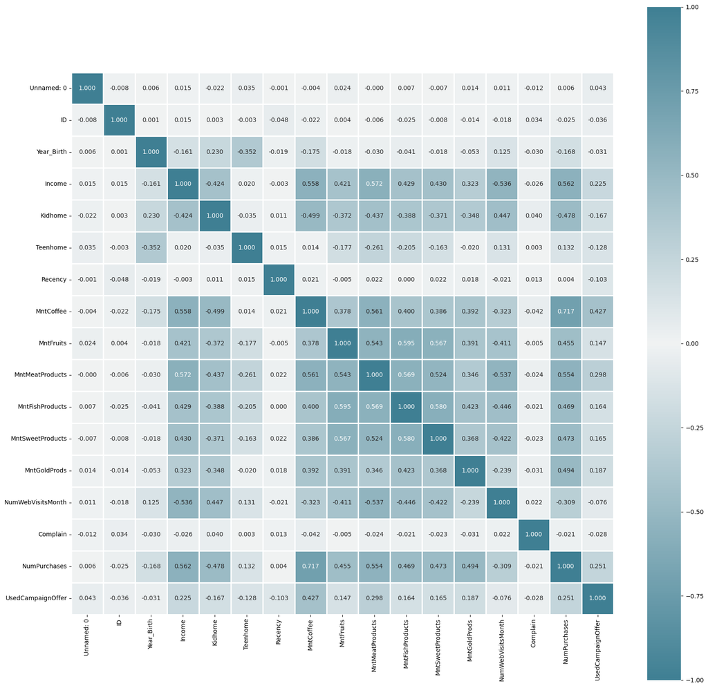

```python
data_corr = data.corr(numeric_only=True)
plt.figure(figsize=(20, 20))
sns.heatmap(data_corr, annot=True, fmt=".3f", cmap = sns.diverging_palette(220, 220, as_cmap=True), linewidths=1, square=True, center=0, vmax=1, vmin=-1)
plt.show()
```

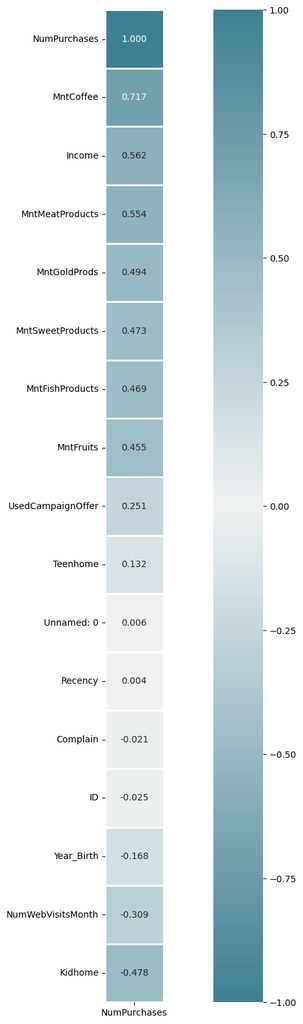

```python
NumPurchases_corr = data_corr[['NumPurchases']].sort_values(by="NumPurchases",ascending=False)
plt.figure(figsize=(20, 20))
sns.heatmap(NumPurchases_corr, annot=True, fmt=".3f", cmap = sns.diverging_palette(220, 220, as_cmap=True), linewidths=1, square=True, center=0, vmax=1, vmin=-1)
plt.show()
```

### unique values for each feature

Having too many unique values can be problematic in classification because it may cause our model to overfit(memorize each single data).

```python
data[NumPurchases_corr.index].nunique()
```

```
NumPurchases           39
MntCoffee             745
Income               1807
MntMeatProducts       558
MntGoldProds          212
MntSweetProducts      177
MntFishProducts       182
MntFruits             158
UsedCampaignOffer       2
Teenhome                3
Unnamed: 0           2236
Recency               100
Complain                2
ID                   2236
Year_Birth             59
NumWebVisitsMonth      15
Kidhome                 3
dtype: int64
```

```python
corr_arr = data_corr["NumPurchases"].drop("NumPurchases").sort_values(ascending=False)
dependent_to_target = corr_arr[abs(corr_arr) > CORR_THRESHOLD]

dependent_to_target
```

```
MntCoffee            0.717111
Income               0.562330
MntMeatProducts      0.554417
MntGoldProds         0.494411
MntSweetProducts     0.472721
MntFishProducts      0.469183
MntFruits            0.455276
UsedCampaignOffer    0.251499
NumWebVisitsMonth   -0.309326
Kidhome             -0.477607
Name: NumPurchases, dtype: float64
```

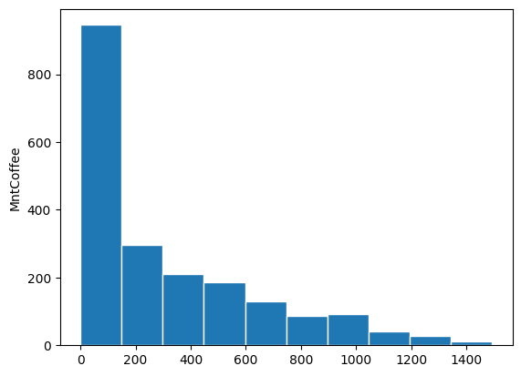

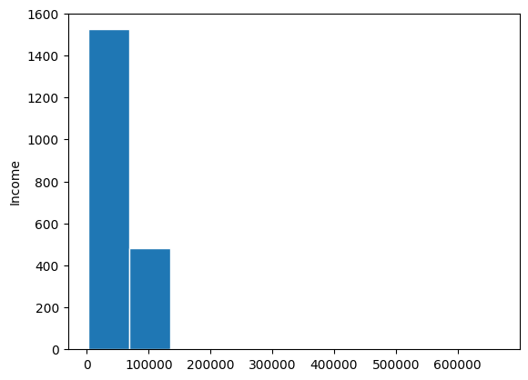

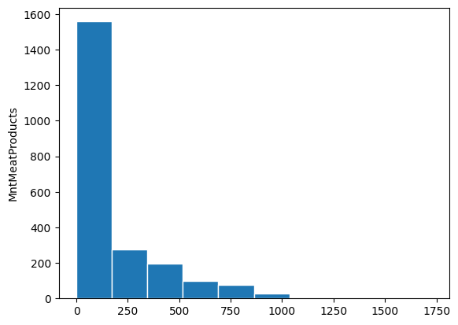

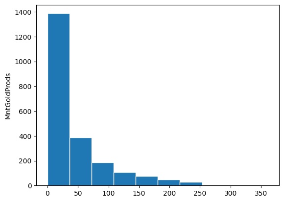

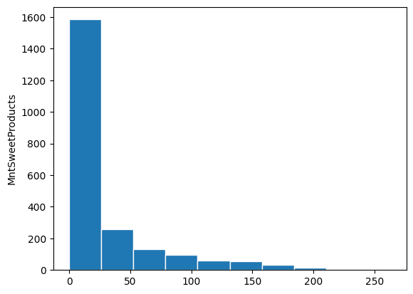

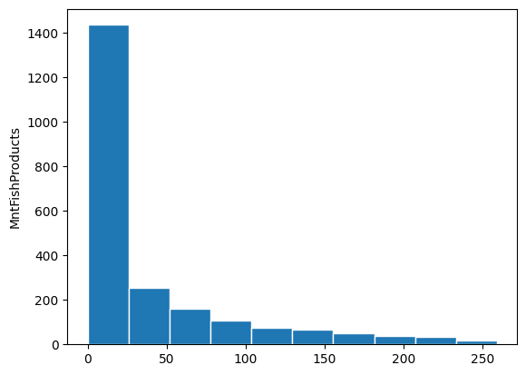

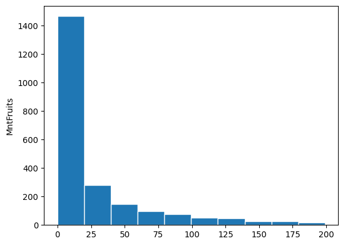

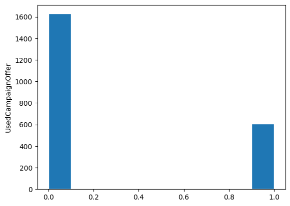

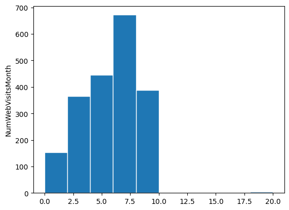

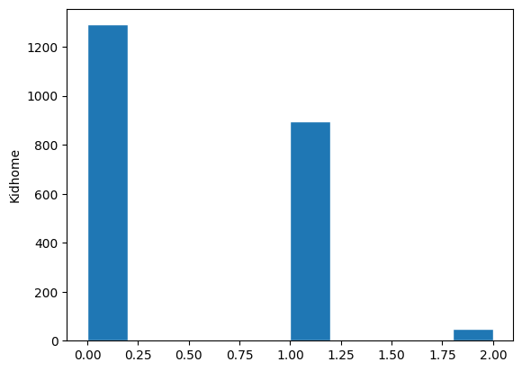

```python
for feature in dependent_to_target.index:
    plt.hist(data[feature], edgecolor='white')
    plt.ylabel(feature)
    plt.show()
```

### Plotting the relationship between the features using hexbin and scatter plots

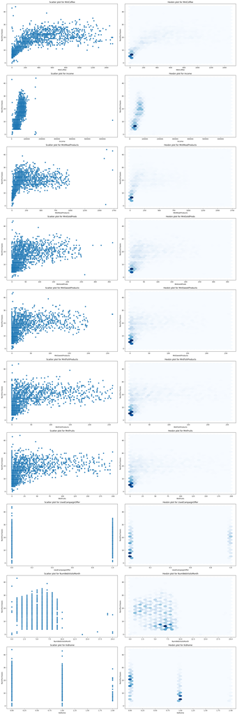

```python
fig, axs = plt.subplots(nrows=len(dependent_to_target.index), ncols=2, figsize=(20, 60))

for i, feature in enumerate(dependent_to_target.index):
    axs[i, 0].scatter(data[feature], data["NumPurchases"])
    axs[i, 0].set_title(f'Scatter plot for {feature}')
    axs[i, 0].set_xlabel(feature)
    axs[i, 0].set_ylabel("NumPurchases")

    axs[i, 1].hexbin(data[feature], data["NumPurchases"], gridsize=30, cmap='Blues')
    axs[i, 1].set_title(f'Hexbin plot for {feature}')
    axs[i, 1].set_xlabel(feature)
    axs[i, 1].set_ylabel("NumPurchases")

plt.tight_layout()
plt.show()
```

## Preprocessing Dataset

### 7. Handle Missing Values Mthodes

#### `Imputation:`

One commonly employed approach is mean imputation, wherein absent values are substituted with the mean of the available data. Likewise, the median and mode of the non-missing data may serve as alternatives. Another strategy involves replacing missing values with the preceding or subsequent observation's value, referred to as forward-fill and backward-fill, respectively. Alternatively, one may opt to predict missing values or introduce a randomly selected value into the dataset.

- **`Filling with Mean:`** Using the average to fill missing values is simple to do and the mean is a good representative of the data as a whole.  
  But sometimes it may not make sense and be impossible to use for a column.
- **`Filling with Median:`**  
  The outlier data can affect the mean negatively.  
  In such cases, it may be better to use the median which is not affected by outliers.
- **`Filling with Mode:`** Mean and median do not work with categorical data.  
  Using the mode can be a alternative for such data.
- **`Random Fill:`**  
  In this method we fill using random values, mostly in the range of the column's minimum and maximum data, or between the categories.
- **`Predicting:`**  
  A more advanced method is to have a way of predicting what the missing value should be based on the other properties of the row.
- **`Forward-fill and Backward-fill:`**  
  In this method we fill the missing values with next or previous observation respectively

#### `Dropping:`

An alternative is to eliminate observations that include missing values. This decision should be approached thoughtfully, as it has the potential to diminish the dataset's size and influence its representativeness. There are two primary methods for this: eliminating columns or eliminating rows.

- **`Dropping Columns:`**  
  In this method we remove any column that has missing values in it.  
  This is usually not wanted because we potentially losing a lot of data.  
  This method should only be considered on columns that have too many missing values; and in fact, its actually the better thing to do in such cases because there is not much data to fill it with good precision.
- **`Dropping Rows:`**  
  Works similarly to dropping columns.  
  If we remove all rows that have missing values, if a column is all missing, then all of the rows will be gone.  
  This method should also only be considered on rows that have most of their properties missing.

Ultimately, in instances where missing data is minimal, one may opt to disregard these values entirely and proceed with the analysis. Nevertheless, it is crucial to ascertain whether the missingness is random or non-random before making this decision.

### 8. Handle Missing Values

regarding to phaze one, `Income`, `MntCoffee`, and `NumWebVisitsMonth` have the most missing data. I have choosen to use `Filling with median`becuase this is to not get affected by outliers and also not be fractional.

```python
data.fillna(data.median(numeric_only=True), inplace=True)
missing_values(data)
```

|  | Missing | Percentage |
| --- | --- | --- |
| Unnamed: 0 | 0 | 0.0 |
| ID | 0 | 0.0 |
| Year_Birth | 0 | 0.0 |
| Education | 0 | 0.0 |
| Marital_Status | 0 | 0.0 |
| Income | 0 | 0.0 |
| Kidhome | 0 | 0.0 |
| Teenhome | 0 | 0.0 |
| Dt_Customer | 0 | 0.0 |
| Recency | 0 | 0.0 |
| MntCoffee | 0 | 0.0 |
| MntFruits | 0 | 0.0 |
| MntMeatProducts | 0 | 0.0 |
| MntFishProducts | 0 | 0.0 |
| MntSweetProducts | 0 | 0.0 |
| MntGoldProds | 0 | 0.0 |
| NumWebVisitsMonth | 0 | 0.0 |
| Complain | 0 | 0.0 |
| NumPurchases | 0 | 0.0 |
| UsedCampaignOffer | 0 | 0.0 |

### 9. Normalize and Standardize

`Normalizing`: Normalizing is the process of scaling the values of a column to a range between 0 and 1. This is done by subtracting the minimum value of the column from each value, and then dividing by the range of the column (i.e., the difference between the maximum and minimum values). Normalizing is useful when the absolute values of the data are not important, but the relative values are. We can use the `MinMaxScaler` method to do this. We can't use normalization when we are not using algorithms such as `KNN` or `Neural Networks` which are based on distance. Below is the formula for the `MinMaxScaler` method:

$$X_{norm} = \frac{X - X_{min}}{X_{max} - X_{min}}$$

`Standardizing`: Standardizing is the process of scaling the values of a column to have a mean of 0 and a standard deviation of 1. This is done by subtracting the mean of the column from each value, and then dividing by the standard deviation of the column. Standardizing is useful when the absolute values of the data are important, and when the data has a normal distribution. Below is the formula for the `StandardScaler` method:

$$X_{std} = \frac{X - \mu}{\sigma}$$

why do we need them:

- `Different scales`: The features in a DataFrame may have different scales, which can cause some features to dominate the others in the analysis. For example, if one feature has values in the range of 0-1 and another feature has values in the range of 0-1000, the second feature will have a much larger impact on the analysis. Normalizing or standardizing the data can ensure that all features have a similar scale and prevent this issue.
- `Outliers`: Outliers in the data can also have a significant impact on the analysis. Normalizing or standardizing the data can reduce the impact of outliers by scaling the data to a more reasonable range.
- `Algorithm requirements`: Some machine learning algorithms require the data to be normalized or standardized in order to work properly. For example, algorithms that use distance measures, such as k-nearest neighbors or clustering algorithms, can be sensitive to the scale of the data. Normalizing or standardizing the data can ensure that these algorithms work properly.
- `Interpretability`: Normalizing or standardizing the data can make the results of the analysis more interpretable. For example, if the data is standardized to have a mean of 0 and a standard deviation of 1, the coefficients of a linear regression model will represent the change in the response variable for a one standard deviation change in the predictor variable.

```python
def standardization(data: pd.DataFrame, exclude_cols: list = []):
    scaler_std = StandardScaler()
    numeric_cols = data.select_dtypes(include="number")
    data[numeric_cols.columns] = scaler_std.fit_transform(numeric_cols)
    data[exclude_cols] = numeric_cols[exclude_cols]

def normalization(data: pd.DataFrame, exclude_cols: list = []):
    scaler_norm = MinMaxScaler()
    numeric_cols = data.select_dtypes(include="number")
    data[numeric_cols.columns] = scaler_norm.fit_transform(numeric_cols)
    data[exclude_cols] = numeric_cols[exclude_cols]
```

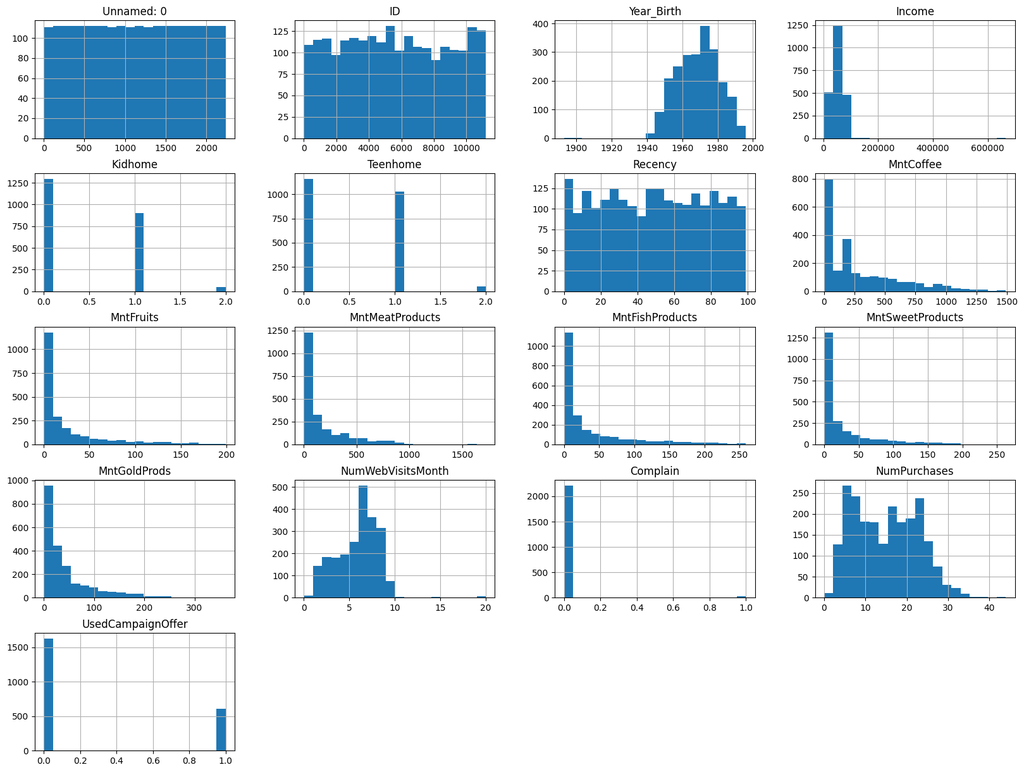

```python
data.hist(bins=20, figsize=(20,15))
plt.show()
```

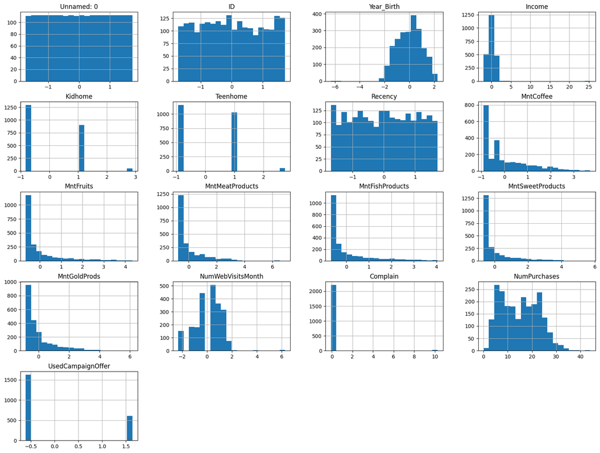

```python
normalization(data, ["NumPurchases"])
standardization(data, ["NumPurchases"])
data.hist(bins=20, figsize=(20,15))
plt.show()
```

### 10. Encoding Categorical Values

- `Label Encoding`: This method assigns a unique integer label to each category in the data. This is useful when the categories have an inherent order or ranking, such as low, medium, and high. The LabelEncoder class from the sklearn.preprocessing module can be used to perform label encoding.

  > Category 1: 0  
  > Category 2: 1  
  > Category 3: 2
- `One-Hot Encoding`: This method creates a binary column for each category in the data, indicating whether the category is present or not. This is useful when the categories do not have an inherent order or ranking, and when the number of categories is small. The get_dummies() function from Pandas can be used to perform one-hot encoding.

  > Category 1: 1, 0, 0  
  > Category 2: 0, 1, 0  
  > Category 3: 0, 0, 1
- `Binary Encoding`: This method creates binary columns for each category in the data, but instead of using a single binary column for each category, it uses a binary code for each category. This is useful when the number of categories is large, as it reduces the number of columns needed for encoding. The BinaryEncoder class from the category_encoders library can be used to perform binary encoding.

  > Category 1: 00  
  > Category 2: 01  
  > Category 3: 10
- `Count Encoding`: This method replaces each category in the data with the number of times it appears in the dataset. This is useful when the frequency of each category is important, and when the number of categories is large. The CountEncoder class from the category_encoders library can be used to perform count encoding.

  > Category 1: 0.5  
  > Category 2: 0.25  
  > Category 3: 0.25
- `Target Encoding`: This method replaces each category in the data with the mean of the target variable for that category. This is useful when the relationship between the categories and the target variable is important, and when the number of categories is large. The TargetEncoder class from the category_encoders library can be used to perform target encoding.

  > Category 1: 0.5  
  > Category 2: 0.25  
  > Category 3: 0.75
- `Hash Encoding`: Hash encoding applies a hashing function to map categories to a fixed number of values. It reduces the dimensionality of the feature space but may introduce collisions.
- `Text Encoding`: Categorical features are often stored as text. Before using them in model training, you can convert these texts into numerical representations such as TF-IDF vectors or Word2Vec embeddings.

for this case, we choose label encoding

```python
display(data.head(10))
```

|  | Unnamed: 0 | ID | Year_Birth | Education | Marital_Status | Income | Kidhome | Teenhome | Dt_Customer | Recency | MntCoffee | MntFruits | MntMeatProducts | MntFishProducts | MntSweetProducts | MntGoldProds | NumWebVisitsMonth | Complain | NumPurchases | UsedCampaignOffer |
| --- | --- | --- | --- | --- | --- | --- | --- | --- | --- | --- | --- | --- | --- | --- | --- | --- | --- | --- | --- | --- |
| 0 | -1.731710 | -0.021260 | -0.984359 | Graduation | Single | 0.244463 | -0.824939 | -0.930615 | 04-09-2012 | 0.306327 | 1.061248 | 1.549983 | 1.679473 | 2.459783 | 1.474847 | 0.856303 | 0.262642 | -0.097369 | 25 | 1.638197 |
| 1 | -1.730164 | -1.053067 | -1.234646 | Graduation | Single | -0.242216 | 1.032627 | 0.905974 | 08-03-2014 | -0.384597 | -0.356526 | -0.636205 | -0.713139 | -0.650933 | -0.631558 | -0.728964 | -0.165396 | -0.097369 | 6 | -0.610427 |
| 2 | -1.728618 | -0.447227 | -0.316926 | Graduation | Together | 0.800509 | -0.824939 | -0.930615 | 21-08-2013 | -0.799151 | -0.356526 | 0.569967 | -0.177016 | 1.343585 | -0.147327 | -0.032993 | 0.262642 | -0.097369 | 21 | -0.610427 |
| 3 | -1.727072 | 0.181406 | 1.268226 | Graduation | Together | -1.055054 | 1.032627 | -0.930615 | 10-02-2014 | -0.799151 | -0.870391 | -0.560819 | -0.651108 | -0.504546 | -0.583134 | -0.748297 | 0.262642 | -0.097369 | 8 | -0.610427 |
| 4 | -1.725526 | -0.082860 | 1.017939 | PhD | Married | 0.250860 | 1.032627 | -0.930615 | 19-01-2014 | 1.549990 | -0.368908 | 0.419196 | -0.216893 | 0.154194 | -0.002057 | -0.554972 | -0.165396 | -0.097369 | 19 | -0.610427 |
| 5 | -1.723980 | 0.570720 | -0.150068 | Master | Together | -0.034859 | -0.824939 | 0.905974 | 09-09-2013 | -1.144613 | 0.705257 | 0.394067 | -0.305509 | -0.687530 | 0.361116 | -0.574304 | 0.262642 | -0.097369 | 22 | -0.610427 |
| 6 | -1.722434 | -1.425442 | 0.183648 | Graduation | Divorced | 0.141177 | -0.824939 | 0.905974 | 13-11-2012 | -0.522782 | -0.176982 | 0.972025 | -0.013078 | 0.227387 | 0.530597 | -0.322981 | 0.262642 | -0.097369 | 21 | -0.610427 |
| 7 | -1.720888 | 0.179866 | 1.351655 | PhD | Married | -0.774122 | 1.032627 | -0.930615 | 08-05-2013 | -0.591874 | -0.669179 | -0.410048 | -0.491601 | -0.632635 | -0.631558 | -0.400311 | 1.118718 | -0.097369 | 10 | -0.610427 |
| 8 | -1.719341 | -0.227313 | 0.433936 | PhD | Together | -0.902167 | 1.032627 | -0.930615 | 06-06-2013 | -1.040975 | -0.861104 | -0.661334 | -0.633385 | -0.632635 | -0.583134 | -0.806295 | 1.546756 | -0.097369 | 6 | 1.638197 |
| 9 | -1.717795 | 0.094241 | -1.568362 | PhD | Together | -1.921536 | 1.032627 | 0.905974 | 13-03-2014 | 0.651789 | -0.817766 | -0.661334 | -0.713139 | -0.669231 | -0.631558 | -0.593637 | 6.255172 | -0.097369 | 2 | 1.638197 |

```python
def encode_categories(data: pd.DataFrame):
    to_encode = data.select_dtypes(include=['category', 'object'])
    data[to_encode.columns] = to_encode.apply(LabelEncoder().fit_transform)
encode_categories(data)
display(data.head(10))
```

|  | Unnamed: 0 | ID | Year_Birth | Education | Marital_Status | Income | Kidhome | Teenhome | Dt_Customer | Recency | MntCoffee | MntFruits | MntMeatProducts | MntFishProducts | MntSweetProducts | MntGoldProds | NumWebVisitsMonth | Complain | NumPurchases | UsedCampaignOffer |
| --- | --- | --- | --- | --- | --- | --- | --- | --- | --- | --- | --- | --- | --- | --- | --- | --- | --- | --- | --- | --- |
| 0 | -1.731710 | -0.021260 | -0.984359 | 2 | 4 | 0.244463 | -0.824939 | -0.930615 | 80 | 0.306327 | 1.061248 | 1.549983 | 1.679473 | 2.459783 | 1.474847 | 0.856303 | 0.262642 | -0.097369 | 25 | 1.638197 |
| 1 | -1.730164 | -1.053067 | -1.234646 | 2 | 4 | -0.242216 | 1.032627 | 0.905974 | 157 | -0.384597 | -0.356526 | -0.636205 | -0.713139 | -0.650933 | -0.631558 | -0.728964 | -0.165396 | -0.097369 | 6 | -0.610427 |
| 2 | -1.728618 | -0.447227 | -0.316926 | 2 | 5 | 0.800509 | -0.824939 | -0.930615 | 444 | -0.799151 | -0.356526 | 0.569967 | -0.177016 | 1.343585 | -0.147327 | -0.032993 | 0.262642 | -0.097369 | 21 | -0.610427 |
| 3 | -1.727072 | 0.181406 | 1.268226 | 2 | 5 | -1.055054 | 1.032627 | -0.930615 | 199 | -0.799151 | -0.870391 | -0.560819 | -0.651108 | -0.504546 | -0.583134 | -0.748297 | 0.262642 | -0.097369 | 8 | -0.610427 |
| 4 | -1.725526 | -0.082860 | 1.017939 | 4 | 3 | 0.250860 | 1.032627 | -0.930615 | 390 | 1.549990 | -0.368908 | 0.419196 | -0.216893 | 0.154194 | -0.002057 | -0.554972 | -0.165396 | -0.097369 | 19 | -0.610427 |
| 5 | -1.723980 | 0.570720 | -0.150068 | 3 | 5 | -0.034859 | -0.824939 | 0.905974 | 189 | -1.144613 | 0.705257 | 0.394067 | -0.305509 | -0.687530 | 0.361116 | -0.574304 | 0.262642 | -0.097369 | 22 | -0.610427 |
| 6 | -1.722434 | -1.425442 | 0.183648 | 2 | 2 | 0.141177 | -0.824939 | 0.905974 | 280 | -0.522782 | -0.176982 | 0.972025 | -0.013078 | 0.227387 | 0.530597 | -0.322981 | 0.262642 | -0.097369 | 21 | -0.610427 |
| 7 | -1.720888 | 0.179866 | 1.351655 | 4 | 3 | -0.774122 | 1.032627 | -0.930615 | 160 | -0.591874 | -0.669179 | -0.410048 | -0.491601 | -0.632635 | -0.631558 | -0.400311 | 1.118718 | -0.097369 | 10 | -0.610427 |
| 8 | -1.719341 | -0.227313 | 0.433936 | 4 | 5 | -0.902167 | 1.032627 | -0.930615 | 119 | -1.040975 | -0.861104 | -0.661334 | -0.633385 | -0.632635 | -0.583134 | -0.806295 | 1.546756 | -0.097369 | 6 | 1.638197 |
| 9 | -1.717795 | 0.094241 | -1.568362 | 4 | 5 | -1.921536 | 1.032627 | 0.905974 | 267 | 0.651789 | -0.817766 | -0.661334 | -0.713139 | -0.669231 | -0.631558 | -0.593637 | 6.255172 | -0.097369 | 2 | 1.638197 |

### 11. Elimination of Columns

I have droped Id and Unnamed because they are unique and not helpuf. Also, I have droped some columns which have low correlation with the target.

```python
data.columns
```

```
Index(['Unnamed: 0', 'ID', 'Year_Birth', 'Education', 'Marital_Status',
       'Income', 'Kidhome', 'Teenhome', 'Dt_Customer', 'Recency', 'MntCoffee',
       'MntFruits', 'MntMeatProducts', 'MntFishProducts', 'MntSweetProducts',
       'MntGoldProds', 'NumWebVisitsMonth', 'Complain', 'NumPurchases',
       'UsedCampaignOffer'],
      dtype='object')
```

```python
# data = data.drop(['Unnamed: 0', 'ID', 'Recency', 'Complain', 'Teenhome', 'Year_Birth'], axis = "columns")
data = data[dependent_to_target.index.union(["NumPurchases"])]
```

```python
data.columns
```

```
Index(['Income', 'Kidhome', 'MntCoffee', 'MntFishProducts', 'MntFruits',
       'MntGoldProds', 'MntMeatProducts', 'MntSweetProducts', 'NumPurchases',
       'NumWebVisitsMonth', 'UsedCampaignOffer'],
      dtype='object')
```

### 12. Train and Test data

- `The training set` is a subset of the available data that is used to train the machine learning model. The model is trained on the input features (also known as predictors or independent variables) and the corresponding output values (also known as labels or dependent variables) in the training set. The goal of training is to learn a mapping between the input features and the output values, so that the model can make accurate predictions on new, unseen data.
- `The test set` is a subset of the available data that is used to evaluate the performance of the machine learning model. The model is applied to the input features in the test set to make predictions, and the predicted output values are compared to the actual output values in the test set. The performance of the model is then evaluated using various metrics, such as accuracy, precision, recall, F1 score, etc.

There are some ways to split data to train and test:

- `Holdout Method`: In this method, a percentage of the data, is randomly assigned to the training set, and the remaining percentage is allocated to the test set.
- `Cross-Validation`: Cross-validation is a technique where the data is divided into multiple subsets or folds. The model is trained and evaluated multiple times, with each fold used as the test set once and the rest as the training set.
  - K-Fold Cross-Validation: The data is divided into K subsets of approximately equal size. The model is trained and evaluated K times, with each fold used as the test set once. The final performance is averaged over the K iterations.
  - Stratified K-Fold Cross-Validation: This method is similar to K-Fold, but it ensures that the distribution of target classes remains consistent across each fold. This is particularly useful when dealing with imbalanced datasets.
- `Leave-One-Out Cross-Validation`: Here, each data point is used as the test set, and the rest of the data is used for training. This method is computationally expensive for large datasets but can provide an unbiased evaluation.
- `Time-based Split`: This method is useful when we have a time series dataset. But it is not useful in this case.

```python
features = data.drop("NumPurchases", axis = "columns")
X_train, X_test, y_train, y_test = train_test_split(features, data["NumPurchases"], test_size=0.2, random_state=42)
display(X_train.head(10))
```

|  | Income | Kidhome | MntCoffee | MntFishProducts | MntFruits | MntGoldProds | MntMeatProducts | MntSweetProducts | NumWebVisitsMonth | UsedCampaignOffer |
| --- | --- | --- | --- | --- | --- | --- | --- | --- | --- | --- |
| 1269 | 0.205055 | 1.032627 | -0.356526 | -0.559441 | -0.535691 | 0.508318 | -0.456155 | -0.655769 | 1.118718 | -0.610427 |
| 1532 | -0.034859 | 1.032627 | -0.876582 | -0.650933 | -0.661334 | -0.767630 | -0.708708 | -0.655769 | 1.118718 | -0.610427 |
| 617 | 0.080394 | 1.032627 | -0.888964 | -0.577740 | -0.510562 | -0.651634 | -0.695416 | -0.534711 | 0.262642 | -0.610427 |
| 1405 | -0.629570 | 1.032627 | -0.594885 | -0.650933 | -0.611077 | -0.245651 | -0.668831 | -0.631558 | 1.546756 | 1.638197 |
| 1134 | 1.381644 | -0.824939 | 1.305798 | 1.435077 | 1.248439 | -0.612969 | 1.010428 | -0.655769 | -1.877547 | 1.638197 |
| 693 | -0.191625 | 1.032627 | -0.697039 | -0.687530 | -0.636205 | -0.245651 | -0.651108 | -0.607346 | 0.690680 | 1.638197 |
| 1104 | -0.055450 | -0.824939 | -0.356526 | -0.687530 | -0.661334 | -0.806295 | -0.704277 | -0.655769 | 0.262642 | -0.610427 |
| 891 | -0.034859 | 1.032627 | -0.904442 | -0.541143 | -0.661334 | -0.806295 | -0.735293 | -0.583134 | 0.690680 | -0.610427 |
| 2006 | 0.814993 | -0.824939 | 0.912660 | 2.606170 | 0.620225 | 0.817638 | 3.389747 | 0.167424 | -1.021471 | -0.610427 |
| 1345 | 1.381644 | -0.824939 | 1.305798 | 1.435077 | 1.248439 | -0.612969 | 1.010428 | -0.655769 | -1.877547 | 1.638197 |

### 13. Validation Data

Validation in data refers to the process of evaluating the performance of a machine learning model on a dataset that is separate from the training dataset. The validation set is typically used to tune the hyperparameter of the model and to estimate the generalization error of the model. The validation set is used to evaluate the performance of the model during the training process. After each epoch of training, the model is evaluated on the validation set to see how well it is generalizing to new data. This allows us to monitor the performance of the model and to make adjustments to the hyperparameters as needed. Once the model has been trained and the hyperparameters have been tuned using the validation set, we can evaluate the final performance of the model on the test set. The test set provides an unbiased estimate of the generalization error of the model, since it has not been used during the training or validation process.

There are several types of validation techniques that can be used in machine learning, including:

- `Holdout validation`: This technique involves splitting the dataset into two parts: a training set and a validation set. The model is trained on the training set and evaluated on the validation set. The performance on the validation set is used to estimate the performance on new, unseen data.
- `Cross-validation`: This technique involves splitting the dataset into k-folds, where k is a user-defined parameter. The model is trained on k-1 folds and evaluated on the remaining fold. This process is repeated k times, with each fold used as the validation set once. The performance on the k validation sets is averaged to estimate the performance on new, unseen data.
- `Leave-one-out validation`: This technique involves using all but one data point for training and the remaining data point for validation. This process is repeated for each data point in the dataset. The performance on the validation sets is averaged to estimate the performance on new, unseen data.

We perfer not having validation in this project

### 14. K-Fold Cross Validation

`K-fold cross-validation`: The data is split into K equally sized folds, and the model is trained and evaluated K times, with each fold used once as the test set and the remaining folds used as the training set.

K-fold cross-validation provides a more robust estimate of a model's performance compared to a single train-validation split. It helps to ensure that the model's evaluation is not dependent on a specific random split of the data, as it evaluates the model on different subsets of the data.

## Training, Testing and Evaluating the Models.

### Linear Regression

Main form of simple linear regression function: $$f(x) = \alpha x + \beta$$

here we want to find the slope ($\alpha$) and bias($\beta$) by minimizing the derivation of the Residual Sum of Squares (RSS) function:

- step 1: Compute RSS of the training data

$$ RSS = \Sigma (y_i - (\hat{\beta} + \hat{\alpha} * x_i) )^2 $$

- step 2: Compute the derivatives of the RSS function in terms of $\alpha$ and $\beta$, and set them equal to 0 to find the desired parameters

$$ \frac{\partial RSS}{\partial \beta} = \Sigma (-f(x_i) + \hat{\beta} + \hat{\alpha} * x_i) = 0$$ $$ \to \beta = \hat{y} - \hat{\alpha} \hat{x} \to (1)$$

$$ \frac{\partial RSS}{\partial \alpha} = \Sigma (-2 x_i y_i + 2 \hat{\beta} x_i + 2\hat{\alpha} x_i ^ 2) = 0 \to (2)$$

$$ (1) , (2) \to \hat{\alpha} = \frac{\Sigma{(x_i - \hat{x})(y_i - \hat{y})}}{\Sigma{(x_i - \hat{x})^2}} $$ $$ \hat{\beta} = \hat{y} - \hat{\alpha} \hat{x}$$

### 16. The most accurate feature

`MntCoffee` feature is the best feature here because it has the highest correlation with the target.

Based on the above formula, implement the function below to compute the parameters of a simple linear regression

```python
def simple_linear_regression(input_feature, output):
    input_mean = input_feature.mean()
    output_mean = output.mean()
    bias = ((input_feature - input_mean) * (output - output_mean)).sum() / ((input_feature - input_mean)**2).sum()
    slope = output_mean - bias * input_mean
    return (bias, slope)
```

Now complete this `get_regression_predictions(...)` function to predict the value of given data based on the calculated intercept and slope

```python
def get_regression_predictions(input_feature, bias, slope):
    return input_feature * bias + slope
```

Now that we have a model and can make predictions, let's evaluate our model using Root Mean Square Error (RMSE). RMSE is the square root of the mean of the squared differences between the residuals, and the residuals is just a fancy word for the difference between the predicted output and the true output.

Complete the following function to compute the RSME of a simple linear regression model given the input_feature, output, intercept and slope:

```python
def get_root_mean_square_error(predicted_values, outputs):
    residuals = predicted_values - outputs
    residuals_sum_sqr = (residuals ** 2).sum()
    mean_residual_sqr = residuals_sum_sqr/len(predicted_values)
    return math.sqrt(mean_residual_sqr)
```

### Evaluation Methods

- `RMSE:(Root Mean Squared Error)` RMSE measures the average distance between the predicted values and the actual values in a dataset. It is calculated as the square root of the average of the squared differences between the predicted and actual values. RMSE is a measure of the spread of the residuals, which are the differences between the predicted values and the actual values. A lower RMSE indicates that the model is better at predicting the actual values.
- `R2 score:` R2 score measures the proportion of the variance in the dependent variable that is explained by the independent variables. It is calculated as 1 minus the ratio of the residual sum of squares (RSS) to the total sum of squares (TSS). R2 score ranges from 0 to 1, with a higher score indicating a better fit of the model to the data.
- `RSS:(Residual Sum of Squares)` The RSS is the sum of the squared differences between the predicted values and the actual values. It measures the total amount of error in the model.
- `MSE:(Mean Squared Error)` MSE measures the average of the squared differences between the predicted values and the actual values. It is calculated as the average of the squared residuals. MSE is a measure of the spread of the residuals, similar to RMSE.

$$ RMSE = \sqrt{\frac{1}{n}\sum_{i=1}^{n}(y_{i,true} - y_{i,pred})^2}$$

where $y_{i,pred}$ is the predicted value, $y_{i,true} $ is the actual value, and mean is the average over all the samples in the dataset.

The RMSE has no bound, thus it becomes challenging to determine whether a particular RMSE value is considered good or bad without any reference point. Instead, we use R2 score. The R2 score is calculated by comparing the sum of the squared differences between the actual and predicted values of the dependent variable to the total sum of squared differences between the actual and mean values of the dependent variable. The R2 score is formulated as below:

$$R^2 = 1 - \frac{SSres}{SStot} = 1 - \frac{\sum_{i=1}^{n} (y_{i,true} - y_{i,pred})^2}{\sum_{i=1}^{n} (y_{i,true} - \bar{y}_{true})^2} $$

Complete the following function to calculate the R2 score of a given input_feature, output, bias, and slope:

```python
def get_r2_score(predicted_values, outputs):
    residuals = predicted_values - outputs
    SSres = (residuals ** 2).sum()
    SStot = ((outputs - outputs.mean())**2).sum()
    return 1 - SSres / SStot
```

Now calculate the fitness of the model. Remember to provide explanation for the outputs in your code!

```python
def test_simple_linear_regression(feature, ax):
    bias, slope = simple_linear_regression(X_train[feature], y_train)
    predicted_values = get_regression_predictions(X_test[feature], bias, slope)
    rmse = get_root_mean_square_error(predicted_values, y_test)
    r2_score = get_r2_score(predicted_values, y_test)

    print(f"{feature}:")
    print(f"RMSE: {rmse:0.3f}, R^2: {r2_score:0.3f}")
    print(f"y = {bias:0.3f} * x + {slope:0.3f}")
    print("------------------------")

    ax.scatter(X_train[feature], y_train)
    x_line = np.linspace(min(data[feature]), max(data[feature]), 100)
    y_line = bias * x_line + slope
    ax.plot(x_line, y_line, color='red', label = f"y = {bias:0.3f} * x + {slope:0.3f}")
    ax.set_ylabel("NumPurchases")
    ax.set_xlabel(feature)
    ax.set_title(feature)
    ax.legend()
```

```
MntCoffee:
RMSE: 5.594, R^2: 0.487
y = 5.165 * x + 14.783
------------------------
Income:
RMSE: 5.967, R^2: 0.417
y = 3.690 * x + 14.768
------------------------
MntMeatProducts:
RMSE: 6.328, R^2: 0.344
y = 4.240 * x + 14.793
------------------------
MntGoldProds:
RMSE: 7.187, R^2: 0.154
y = 3.855 * x + 14.689
------------------------
MntSweetProducts:
RMSE: 7.084, R^2: 0.178
y = 3.733 * x + 14.757
------------------------
MntFishProducts:
RMSE: 7.033, R^2: 0.190
y = 3.552 * x + 14.701
------------------------
```

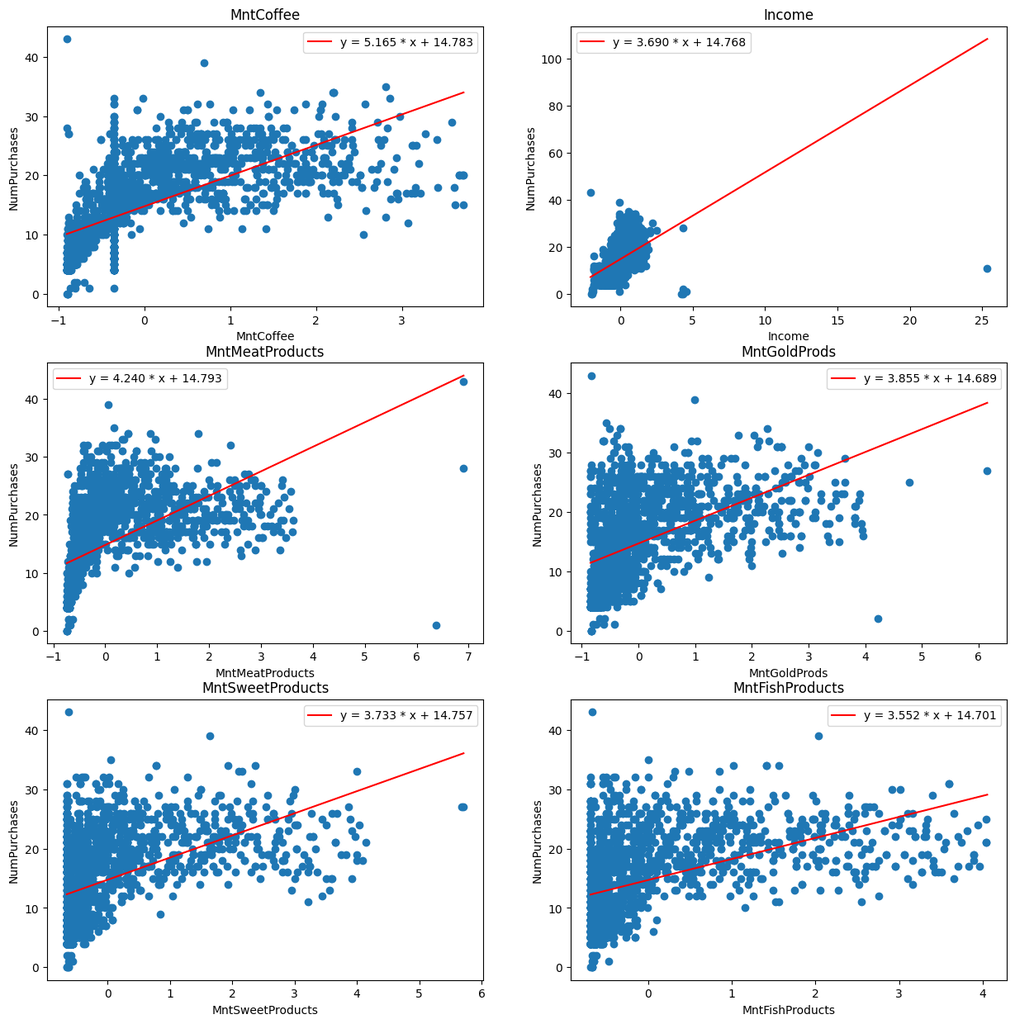

```python
designated_feature_list = list(NumPurchases_corr.index)[1:7]

figure, axs = plt.subplots(nrows=3, ncols=2, figsize=(15,15))
axs = axs.flatten()
for ax, feature in zip(axs, designated_feature_list):
    test_simple_linear_regression(feature, ax)
```

When the relationship between the independent and dependent variables is linear, linear regression can perform well but if the relationship between the variables is non-linear or there is a lot of noise in the data, linear regression may not be the best choice and other models may be more appropriate.

As mentioned above, the R2 scores for all the models are relatively low, which suggests that the independent variables may not be very good predictors of the dependent variable.

# Multiple Regression

Multiple regression is a statistical technique that aims to model the relationship between a dependent variable and two or more independent variables.

Multiple regression with n independent variables is expressed as follows:

$$f(x) = \beta _{0} + \beta_{1} x_{1} + \beta_{2} x_{2} + \beta_{3} x_{3} + \beta_{4} x_{4} + ... + \beta_{n} x_{n} + c $$

To optimize the model for accurate predictions, multiple regression commonly employs iterative algorithms such as gradient descent.

The main goal of the optimization process is to make our predictions as close as possible to the actual values. We measure the prediction error using a cost function, usually denoted as $J(\beta)$.

$$ J(\beta)= \frac {1}{2m} Σ_{i=0}^{m-1}(y_i - (\hat \beta _{0} + \hat \beta_{1} x_{1} + \hat \beta_{2} x_{2} + \hat \beta_{3} x_{3} + \hat \beta_{4} x_{4} + ... + \hat \beta_{n} x_{n}) )^2 $$

Gradient descent iteratively adjusts the coefficients $(\beta_i)$ to minimize the cost function. The update rule for each coefficient is:

$$\beta_{i} = \beta _ {i} - \alpha \frac {∂J(\beta)}{∂\beta_{i}}$$

$$ \frac {∂J(\beta)}{∂\beta_{i}} = \frac {1}{m}Σ_{j=0}^{m-1}(y_j - (\hat \beta _{0} + \hat \beta_{1} x_{j1} + \hat \beta_{2} x_{j2} + \hat \beta_{3} x_{j3} + \hat \beta_{4} x_{j4} + ... + \hat \beta_{n} x_{jn})) x_{ji} $$

## Predicting output given regression weights

Based on the formula above and [np.dot()](https://numpy.org/doc/stable/reference/generated/numpy.dot.html) method, complete this function to compute the predictions for an entire matrix of features given the matrix, bias, and the weights. Provide an explanation of np.dot method and the reasoning behind using this method in your code:

```python
def predict_output(feature_matrix, weights, bias):
    return np.dot(feature_matrix, weights) + bias
```

## Computing the Derivative

As we saw, the cost function is the sum over the data points of the squared difference between an observed output and a predicted output.

Since the derivative of a sum is the sum of the derivatives, we can compute the derivative for a single data point and then sum over data points. We can write the squared difference between the observed output and predicted output for a single point as follows:

$$ (output - (const* w _{0} + [feature_1] * w_{1} + ...+ [feature_n] * w_{n} ))^2 $$

With n feautures and a const , So the derivative will be :

$$ 2 * (output - (const* w _{0} + [feature_1] * w_{1} + ...+ [feature_n] * w_{n} )) $$

The term inside the paranethesis is just the error (difference between prediction and output). So we can re-write this as:

$$2 * error*[feature_i] $$

That is, the derivative for the weight for feature i is the sum (over data points) of 2 times the product of the error and the feature itself. In the case of the constant then this is just twice the sum of the errors!

Recall that twice the sum of the product of two vectors is just twice the dot product of the two vectors. Therefore the derivative for the weight for feature_i is just two times the dot product between the values of feature_i and the current errors.

With this in mind, complete the following derivative function which computes the derivative of the weight given the value of the feature (over all data points) and the errors (over all data points).

```python
def feature_derivative(errors, feature):
    return 2 * np.dot(errors, feature)
```

## Gradient Descent

Now we will write a function that performs a gradient descent. The basic premise is simple. Given a starting point we update the current weights by moving in the negative gradient direction. Recall that the gradient is the direction of increase and therefore the negative gradient is the direction of decrease and we're trying to minimize a cost function.

The amount by which we move in the negative gradient direction is called the 'step size'. We stop when we are 'sufficiently close' to the optimum. We define this by requiring that the magnitude (length) of the gradient vector to be smaller than a fixed 'tolerance'.

With this in mind, complete the following gradient descent function below using your derivative function above. For each step in the gradient descent we update the weight for each feature befofe computing our stopping criteria.

```python
def regression_gradient_descent(feature_matrix, outputs, initial_weights, bias, step_size, tolerance):
    weights = np.array(initial_weights)
    converged = False
    while not converged:
        predictions = predict_output(feature_matrix, weights, bias)
        errors = outputs - predictions

        gradient = - feature_derivative(feature_matrix.T, errors)
        weights -= step_size * gradient

        bias_gradient = -2 * np.sum(errors)
        bias -= step_size * bias_gradient

        if np.linalg.norm(gradient) < tolerance:
            converged = True

    return weights, bias
```

```python
# Utility functions for multiple regression

def normalize_features(chosen_features, data_frame):
    for feature in chosen_features:
        data_frame[feature] = (data_frame[feature] - data_frame[feature].mean()) / data_frame[feature].std()
    return data_frame


def n_feature_regression(chosen_feature_matrix, target_matrix, keywords):
    initial_weights = keywords['initial_weights']
    step_size = keywords['step_size']
    tolerance = keywords['tolerance']
    bias = keywords['bias']

    weights, bias = regression_gradient_descent(chosen_feature_matrix, target_matrix, initial_weights, bias, step_size,
                                                tolerance)

    return weights, bias

def get_weights_and_bias(chosen_features):
    """
    Computes the weights and bias for a general n feature model.
    :param chosen_features:  list of features to perform multiple regression on
    :return: chosen_feature_matrix, computed weights and bias via regression
    """
    keywords = {
        'initial_weights': np.array([.5]*len(chosen_features)),
        'step_size': 1.e-4,
        'tolerance': 1.e-10,
        'bias': 0
    }

    chosen_feature_dataframe = X_train[chosen_features]
    chosen_feature_matrix = chosen_feature_dataframe.to_numpy()

    target_column = y_train
    target_matrix = target_column.to_numpy()

    train_weights, bias = n_feature_regression(chosen_feature_matrix, target_matrix, keywords)

    return chosen_feature_matrix, train_weights, bias
```

## Two Feature Regression

In this part, you should choose 2 features and implement multiple regression on them :

```python
chosen_features = list(NumPurchases_corr.index[1:3])
chosen_feature_matrix, train_weights, bias = get_weights_and_bias(chosen_features)
```

```python
predictions = predict_output(X_test[chosen_features], train_weights, bias)
```

```python
RMSE = get_root_mean_square_error(predictions, y_test)
R2_score = get_r2_score(predictions, y_test)

print("RMSE:", RMSE)
print("R2 Score :", R2_score)
```

```
RMSE: 5.154059194347789
R2 Score : 0.5649468002713267
```

## Three Feature Regression

Now repeat the steps for 3 features

```python
chosen_features = list(NumPurchases_corr.index[1:4])
chosen_feature_matrix, train_weights, bias = get_weights_and_bias(chosen_features)

predictions = predict_output(X_test[chosen_features], train_weights, bias)

RMSE = get_root_mean_square_error(predictions, y_test)
R2_score = get_r2_score(predictions, y_test)

print("RMSE     :", RMSE)
print("R2 Score :", R2_score)
```

```
RMSE     : 5.043479725737847
R2 Score : 0.583414526723066
```

## Five Feature Regression

Finally, repeat the steps for 5 features

Explain the differences in the results and the reasoning behind these variations.

```python
chosen_features = list(NumPurchases_corr.index[1:6])
chosen_feature_matrix, train_weights, bias = get_weights_and_bias(chosen_features)

predictions = predict_output(X_test[chosen_features], train_weights, bias)

RMSE = get_root_mean_square_error(predictions, y_test)
R2_score = get_r2_score(predictions, y_test)

print("RMSE     :", RMSE)
print("R2 Score :", R2_score)
```

```
RMSE     : 5.012104907432378
R2 Score : 0.5885814511324924
```

We could get a better result by increasing the degree of regression but as we saw, `R2 Score` increases by increasing the number of featurss. On the other hand, increasing the features can result in overfitted model.

## Classification using Decision Tree, K-Nearest-Neighbors and logistic regression.

First we add a column named `PurchaseRate` which has labels(boolean) instead of numeric values.

```python
data['PurchaseRate'] = (data["NumPurchases"] > data["NumPurchases"].median()).astype(int)
features = data.drop(["NumPurchases", "PurchaseRate"], axis="columns")
X_train, X_test, y_train, y_test = train_test_split(features, data["PurchaseRate"], test_size=0.2, random_state=42)
display(y_train)
display(y_test)
```

```
1269    1
1532    0
617     0
1405    0
1134    1
       ..
1638    1
1095    0
1130    1
1294    0
860     0
Name: PurchaseRate, Length: 1788, dtype: int32
```

```
1752    0
367     1
1247    1
849     1
1747    1
       ..
1800    0
178     1
471     1
1455    1
2160    0
Name: PurchaseRate, Length: 448, dtype: int32
```

### Grid Search CV

`GridSearchCV` GridSearch refers to a hyperparameter tuning technique commonly used in machine learning to find the optimal set of hyperparameters for a model. The input parameters are :

- `estimator`: The model object that will be used to fit the data.
- `param_grid`: A dictionary or a list of dictionaries that specifies the hyperparameters to search over.
- `cv`: The cross-validation strategy to use.
- `scoring`: The scoring metric to use to evaluate the performance of the model.
- `n_jobs`: The number of CPU cores to use for parallel processing. Setting `n_jobs=-1` will use all available CPU cores.
- `verbose`: The level of verbosity during the search process. Setting `verbose=1` will print progress messages during the search.

### Confusion Matrix

|  |  | **Predicted** | **Results** |
| --- | --- | --- | --- |
|  | *Value* | *0* | *1* |
| **Actual** | *0* | TN | FP |
| **Results** | *1* | FN | TP |

- **TN** *(True Negative):* The actual result is false, and the model correctly predicted it as false.
- **FP** *(False Positive):* The actual result is false, but the model wrongly predicted it as true.
- **FN** *(False Negative):* The actual result is true, but the model wrongly predicted it as false.
- **TP** *(True Positive):* The actual result is true, and the model correctly predicted it as true.

$$Accuracy = \frac{TP + TN}{TP + TN + FP + FN}$$ $$Precision = \frac{TP}{TP + FP}$$ $$Recall = \frac{TP}{TP + FN}$$

This class can be used to calculate metrics for different models and show the result.

```python
class Classifier():
    def __init__(self, classifier, grid_search_params, X_train, y_train):
        self.X_train = X_train
        self.y_train = y_train
        self.classifier = classifier
        self.grid_search_params = grid_search_params
        self.classifier.fit(self.X_train, self.y_train)
        self.train_accuracy = self.classifier.score(self.X_train, self.y_train)

    def get_train_accuracy(self):
        return self.train_accuracy

    def calc_accuracy(self, X_test, y_test):
        return self.classifier.score(X_test, y_test)

    def grid_search(self, X_test, y_test):
        grid = GridSearchCV(self.classifier, self.grid_search_params, scoring='accuracy', cv=5, n_jobs = -1)
        grid.fit(self.X_train, self.y_train)
        test_score = grid.score(X_test, y_test)
        self.best_params = grid.best_params_
        return grid, test_score

    def draw_confusion_matrix(self, X_test, y_test):
        preds = self.classifier.predict(X_test)
        confusion_matrix = metrics.confusion_matrix(y_test, preds)
        _, ax = plt.subplots(figsize=(8, 6))
        matrix_plot = metrics.ConfusionMatrixDisplay(confusion_matrix)
        matrix_plot.plot(cmap='Blues', ax = ax)
        plt.title('Confusion Matrix')
        plt.show()

    def run(self, X_test, y_test):
        print(f"Initial model's test accuracy: {self.classifier.score(X_test, y_test): 0.3f}")
        grid, test_score = self.grid_search(X_test, y_test)
        print(f"Best model's train accuracy score: {grid.score(self.X_train, self.y_train):0.3f}")
        print(f"Best model's test score: {test_score:0.3f}")
        print(f"Best hyperparameters: {grid.best_params_}")
        self.draw_confusion_matrix(X_test, y_test)
```

### Decision Trees

`Decision trees` are intuitive machine learning models used for classification and regression. They make a sequence of decisions based on features to predict outcomes. The tree structure consists of nodes, branches, and leaves. At each node, a feature is chosen to split the data, creating child nodes. The process continues recursively until a stopping criterion is met. Leaf nodes represent predictions. Decision trees are easy to understand and handle various data types, but they can overfit. Pruning and ensemble methods can address overfitting. Decision trees are popular for their interpretability and versatility.

some important hyper-parameters for this model:

- `criterion`: The function used to measure the quality of a split. The two options availabel are *gini* and *entropy*.
- `max_depth`: The maximum depth of the decision tree. A larger value of `max_depth` can capture more complex patterns in the data, but may also lead to overfitting. A smaller value of `max_depth` may lead to underfitting.
- `min_samples_split`: The minimum number of samples required to split an internal node.
- `min_samples_leaf`: The minimum number of samples required to be at a leaf node.
- `splitter`: The strategy used to choose the split at each node. The two options here are *random* and *best*.

```
Initial model's test accuracy:  0.908
Best model's train accuracy score: 0.932
Best model's test score: 0.924
Best hyperparameters: {'criterion': 'gini', 'max_depth': 5, 'min_samples_leaf': 6, 'min_samples_split': 2, 'random_state': 54, 'splitter': 'best'}
```

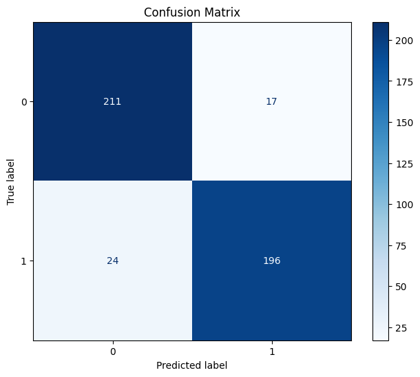

```python
DT_grid_search_params = {
        "criterion": ["gini", "entropy"],
        "splitter": ["best", "random"],
        "max_depth": range(2, 9),
        "min_samples_split": range(2, 9),
        "min_samples_leaf": range(2, 9),
        "random_state": [54],
}

DT = Classifier(DecisionTreeClassifier(), DT_grid_search_params, X_train, y_train)
DT.run(X_test, y_test)
```

### K-Nearest-Neighbours

`KNN` is a simple and effective algorithm for classification and regression. It finds the K nearest neighbors to a new instance in the training data and determines its class or value based on majority voting or averaging. KNN is non-parametric and doesn't assume a specific data distribution. The choice of K is important, as it affects the model's bias-variance trade-off. KNN is easy to understand but can be computationally expensive for large datasets.

some important hyper-parameters for this model:

- `n_neighbors`: The number of neighbors `k` to consider when making a prediction. A larger value of `k` can help reduce the effect of noise in the data, but may also lead to underfitting. A smaller value of `k` can help capture more complex patterns in the data, but may also lead to overfitting.
- `algorithm`: The algorithm used to compute the nearest neighbors. the options are *auto* ,*ball_tree*, *kd_tree*, and *brute*.
- `metric`: The distance metric to use for the tree.

```
Initial model's test accuracy:  0.920
Best model's train accuracy score: 0.928
Best model's test score: 0.908
Best hyperparameters: {'metric': 'euclidean', 'n_neighbors': 9}
```

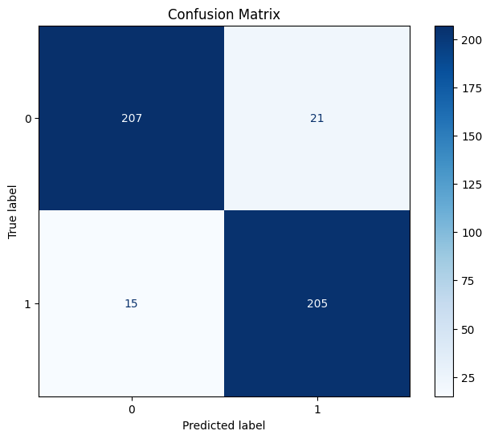

```python
KNN_grid_search_params = {
        "n_neighbors": range(2,100),
        "metric": ["euclidean", "manhattan", "minkowski"]
}
KNN = Classifier(KNeighborsClassifier(), KNN_grid_search_params, X_train, y_train)
KNN.run(X_test, y_test)
```

### Logistic Regression

`Logistic regression` Logistic Regression is a type of supervised learning algorithm that is mostly used for classification problems. It works by modeling the probability of a binary outcome (e.g., 0 or 1) as a function of the input features. The output of the logistic regression model is a probability score between 0 and 1, which can be interpreted as the likelihood of the binary outcome. Logistic regression is a parametric algorithm, which means that it makes assumptions about the underlying distribution of the data. Logistic regression is easy to interpret and can handle both categorical and numerical data. The equation for logistic regression is:

$$(P(y=1|X)) = \sigma(z) = \frac{1}{1 + e^{-z}}$$ $$z = w_1x_1 + w_2x_2 + ... + w_nx_n + b$$

where $w_i$ is the weight asscosiated to $i^{th}$ feature.  
The model estimates the optimal coefficients that minimize the difference between the predicted probabilities and the actual labels in the training data. Predictions are made by calculating the probability and applying a decision threshold.

some important hyper-parameters for this model:

- `Penalty`: Logistic regression can use either L1 or L2 regularization to prevent overfitting. The `penalty` hyperparameter controls which type of regularization to use. L1 regularization can be used to perform feature selection by setting some coefficients to zero, while L2 regularization can be used to shrink the coefficients towards zero.
- `C`: The `C` hyperparameter controls the strength of the regularization. A smaller value of `C` results in stronger regularization, which can help prevent overfitting but may also lead to underfitting.
- `Solver`: Logistic regression can use different optimization algorithms to find the optimal coefficients. The `solver` hyperparameter controls which algorithm to use. The most common solvers are *lbfgs*, *liblinear*, *newton-cg*, *sag*, *saga*.

```
Initial model's test accuracy:  0.911
Best model's train accuracy score: 0.895
Best model's test score: 0.913
Best hyperparameters: {'C': 10, 'penalty': 'l2', 'solver': 'newton-cg'}
```

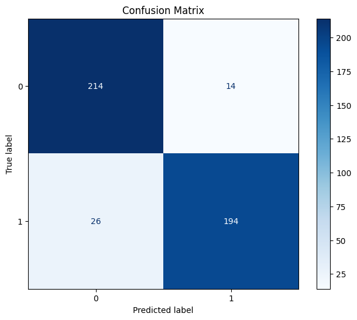

```python
LR_grid_search_params = {
    'C': [0.001, 0.01, 0.1, 1, 10, 100, 1000] + list(range(11,30,1)),
    "penalty": ["l2"],
    "solver": ["newton-cg", "lbfgs", "liblinear", "sag", "saga"],
}
LR = Classifier(LogisticRegression(max_iter=500), LR_grid_search_params, X_train, y_train)
LR.run(X_test, y_test)
```

### Overfitting and Underfitting

- `Overfitting` occurs when a model is too complex and fits the training data too closely. This means that the model has learned the noise in the training data, rather than the underlying patterns, and is not able to generalize well to new, unseen data. Overfitting can occur when the model has too many parameters relative to the amount of training data, or when the model is trained for too many iterations. Overfitting can be detected by evaluating the performance of the model on a separate test set, and comparing it to the performance on the training set. If the performance on the test set is significantly worse than the performance on the training set, then the model is likely overfitting.
- `Underfitting` occurs when a model is too simple and is not able to capture the underlying patterns in the data. This means that the model is not able to fit the training data well, and is not able to generalize well to new, unseen data. Underfitting can occur when the model has too few parameters relative to the complexity of the data, or when the model is trained for too few iterations. Underfitting can be detected by evaluating the performance of the model on the training set, and comparing it to the performance on the test set. If the performance on both the training set and the test set is poor, then the model is likely underfitting.

As we can see both of the scores are pretty good and we don't have overfitting or underfitting. A more important point to notice here is that because we are using the best params the train score tends to be high.

## Ensemble Learning

`Random forest` is a type of ensemble learning algorithm that is used for both classification and regression problems. It works by constructing a multitude of decision trees at training time and outputting the class that is the mode of the classes (classification) or mean prediction (regression) of the individual trees.

The random forest algorithm works by randomly selecting a subset of the input features and a subset of the training data for each decision tree. This process is repeated for each decision tree in the forest, resulting in a set of diverse decision trees that are trained on different subsets of the data. The output of the random forest algorithm is the class that is the mode of the classes (classification) or mean prediction (regression) of the individual trees.

The random forest algorithm has several advantages over a single decision tree.

- it is less prone to overfitting than a single decision tree, because the diversity of the decision trees in the forest reduces the risk of learning the noise in the data.
- it can handle both categorical and numerical data, and can handle missing values and outliers. Third, it can provide estimates of feature importance, which can be used to identify the most important features for the classification or regression problem.

Here are some of the most important hyperparameters of Random Forest:

1. `n_estimators`: The number of decision trees in the Random Forest. A larger value of `n_estimators` can improve the performance of the model, but may also increase the training time and memory usage.
2. `criterion`: The function used to measure the quality of a split. The default is 'gini', which uses the Gini impurity measure. Another option is 'entropy', which uses the information gain measure.
3. `max_depth`: The maximum depth of the decision trees in the Random Forest. A larger value of `max_depth` can capture more complex patterns in the data, but may also lead to overfitting. A smaller value of `max_depth` can help prevent overfitting but may also lead to underfitting.
4. `min_samples_split`: The minimum number of samples required to split an internal node. A larger value of `min_samples_split` can help prevent overfitting but may also lead to underfitting.
5. `min_samples_leaf`: The minimum number of samples required to be at a leaf node. A larger value of `min_samples_leaf` can help prevent overfitting but may also lead to underfitting.
6. `max_features`: The maximum number of features to consider when making a split. The default is 'auto', which uses the square root of the number of features. Another option is 'sqrt', which uses the square root of the number of features.
7. `class_weight`: The weight function used in the classification. The default is None, which means all classes have equal weight. Another option is 'balanced', which automatically adjusts the weights based on the number of samples in each class.
8. `random_state`: Controls the randomness of the estimator. If an integer is given, the randomness will be deterministic and the results will be reproducible.

```
Initial model's test accuracy:  0.935
Best model's train accuracy score: 0.956
Best model's test score: 0.926
Best hyperparameters: {'criterion': 'gini', 'max_depth': 7, 'n_estimators': 14}
```

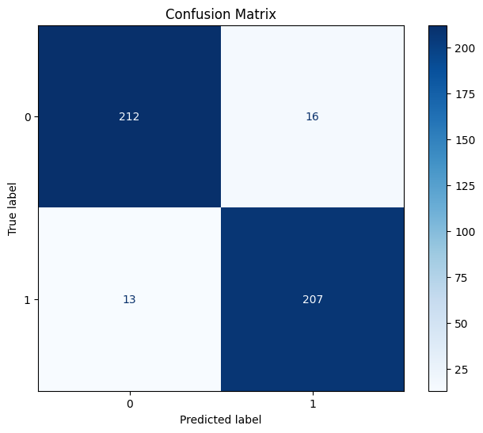

```python
RF_grid_search_params = {
    'n_estimators': range(2,20),
    'criterion': ['entropy', 'gini'],
    'max_depth': range(5, 10),
}
RF_classifier = RandomForestClassifier()
RF = Classifier(RF_classifier, RF_grid_search_params, X_train, y_train)
RF.run(X_test, y_test)
```

Increasing the `n_estimators` and `max_depth` hyperparameters in the `RandomForestClassifier` can help improve the performance of the model in different ways.

```python
def hyper_param_comp(param_range, init_params, param):
    test_accs = []
    train_accs = []
    for i in param_range:
        init_params[param] = i
        classifier = RandomForestClassifier(criterion=init_params['criterion'], max_depth=init_params['max_depth'], n_estimators=init_params['n_estimators'])
        RF = Classifier(classifier, RF_grid_search_params, X_train, y_train)
        test_accs.append(RF.calc_accuracy(X_test, y_test))
        train_accs.append(RF.train_accuracy)

    plt.plot(param_range, test_accs, color='blue', label='test')
    plt.plot(param_range, train_accs, color='red', label='train')
    plt.xlabel(param)
    plt.ylabel('Accuracy')
    plt.legend(loc="lower right")
```

Increasing the `n_estimators` hyperparameter increases the number of decision trees in the Random Forest. This can help improve the performance of the model by reducing the variance of the model and making it more robust to noise in the data. However, increasing the **n_estimators** hyperparameter can also increase the training time and memory usage of the model.

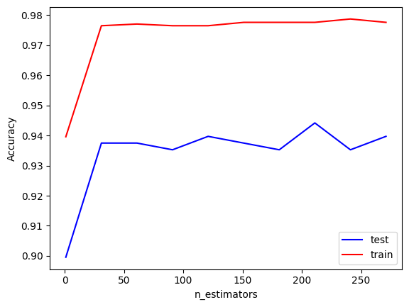

```python
params = {
        'criterion': 'gini',
        'max_depth': 9,
        'n_estimators': 1,
}
hyper_param_comp(range(1, 300, 30), params, 'n_estimators')
```

Increasing the `max_depth` hyperparameter increases the maximum depth of the decision trees in the Random Forest. This can help improve the performance of the model by allowing the decision trees to capture more complex patterns in the data. However, increasing the **max_depth** hyperparameter can also increase the risk of overfitting.

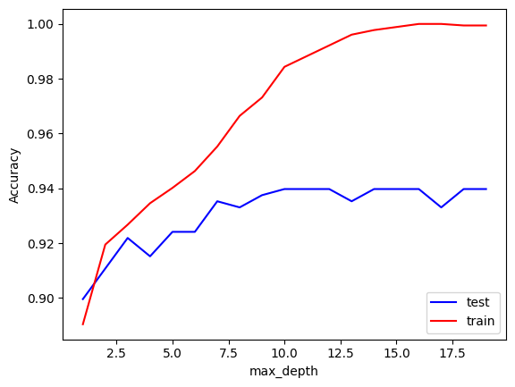

```python
params = {
        'criterion': 'gini',
        'max_depth': 1,
        'n_estimators': 40,
}
hyper_param_comp(range(1, 20), params, 'max_depth')
```

It's important to note that increasing these hyperparameters should be done with caution, as they can also increase the risk of overfitting and lead to poor generalization performance. It's important to balance the complexity of the model with the amount of data available, and to use techniques such as cross-validation and regularization to prevent overfitting.

### Bias and Variance

`Bias` refers to the error introduced by approximating a real-world problem with a simplified model. It represents the model's tendency to consistently predict values that are different from the true values. A high bias indicates that the model is too simplistic and unable to capture the underlying patterns in the data. It typically leads to underfitting, where the model fails to learn the training data properly and performs poorly on both the training and test data.

`Variance` refers to the variability of model predictions for different training datasets. It quantifies how much the model's predictions fluctuate as we change the training data. A high variance indicates that the model is overly sensitive to the training data and captures noise or random fluctuations instead of the true patterns. High variance leads to overfitting, where the model performs well on the training data but fails to generalize to new, unseen data.

- Decision Trees: Decision Trees have high variance because they are prone to overfitting. Decision Trees can fit the training data too closely and capture noise in the data rather than the underlying patterns. This can lead to poor generalization performance on new, unseen data.
- Random Forests: Random Forests have low variance because they are more robust models that can generalize well to new, unseen data. By combining the predictions of multiple decision trees, Random Forests can reduce the risk of overfitting and improve the generalization performance of the model.

```python
best_DT_classifier = DecisionTreeClassifier(** DT.best_params)
best_RF_classifier = RandomForestClassifier(** RF.best_params)
best_DT_classifier.fit(X_train,y_train)
best_RF_classifier.fit(X_train,y_train)

_, dt_bias, dt_var = bias_variance_decomp(best_DT_classifier,
                                            X_train.values,
                                            y_train.values,
                                            X_test.values,
                                            y_test.values,
                                            loss='mse',
                                            num_rounds=100)

_, rf_bias, rf_var = bias_variance_decomp(best_RF_classifier,
                                            X_train.values,
                                            y_train.values,
                                            X_test.values,
                                            y_test.values,
                                            loss='mse',
                                            num_rounds=100)

print(f'Decision Tree Bias:     {dt_bias:.2f}')
print(f'Decision Tree Variance: {dt_var:.2f}')
print(f'Random Forest Bias:     {rf_bias:.2f}')
print(f'Random Forest Variance: {rf_var:.2f}')
```

```
Decision Tree Bias:     0.05
Decision Tree Variance: 0.03
Random Forest Bias:     0.06
Random Forest Variance: 0.02
```

Random forests are an ensemble method that combines multiple decision trees to reduce variance and improve generalization but Decision Trees have more varaince and less bias because they tend to overfit with training data.

```
[Text(0.455, 0.9166666666666666, 'x[6] <= -0.476\ngini = 0.5\nsamples = 1788\nvalue = [915, 873]'),
```

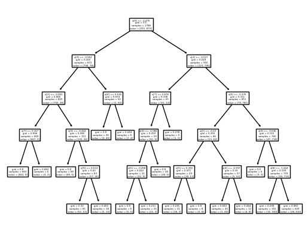

```python
plot_tree(best_DT_classifier)
```

## Differential Privacy

### Effect of adding noise to data on privacy

The objective behind introducing noise is to obfuscate the dataset sufficiently, rendering the identification of specific individuals a challenging endeavor. By incorporating random or perturbed values into the original data, the task of tracing data points back to individual entities becomes intricate. This measure serves to mitigate the risks associated with re-identification and inference attacks, wherein malicious actors seek to discern individuals by scrutinizing patterns and relationships in the data.

Differential privacy furnishes a precise mathematical definition along with assurances for privacy-preserving data analysis. By embedding noise within the framework of differential privacy, it ensures a quantifiable level of privacy protection while permitting the extraction of meaningful analysis and insights from the data.

While the addition of noise can undoubtedly augment privacy and security measures, it is imperative to conscientiously weigh this against potential trade-offs concerning data quality and utility.

### Exponential noise vs Laplace noise

- `Exponential noise`: Exponential noise, also referred to as the Gaussian mechanism, stands out as a widely adopted noise mechanism within the realm of differential privacy. This mechanism introduces random noise to the computation's output, contingent upon the sensitivity of said computation. The sensitivity of a computation denotes the extent to which the computation's output can undergo changes upon the addition or removal of a single data point.  
  In the context of exponential noise, the quantity of noise incorporated adheres to a Gaussian (normal) distribution. The magnitude of this noise is contingent upon a parameter termed the privacy budget, conventionally represented as ε. A diminished value of ε translates to more robust privacy assurances, albeit potentially resulting in more pronounced noisy outputs. Conversely, a larger ε value entails weaker privacy assurances but contributes to outputs with reduced noise.
- `Laplace noise`: The Laplace mechanism is another noise mechanism commonly used in differential privacy. Similar to the exponential mechanism, it adds noise to the output of a computation based on the sensitivity of the computation. However, instead of following a Gaussian distribution, the noise added by the Laplace mechanism follows a Laplace distribution.

The Laplace distribution distinguishes itself through its probability density function, exhibiting heavier tails in contrast to the Gaussian distribution. Consequently, the Laplace mechanism is prone to introducing larger quantities of noise when juxtaposed with the exponential mechanism, all within the confines of an identical privacy budget ε. The Laplace mechanism tends to be the favored choice in scenarios where the computation's sensitivity is constrained, and the privacy budget ε is relatively modest. In such cases, it can afford more robust privacy assurances with a diminished level of noise.

```python
def noise_gen(data, sensitivity, epsilon=1.0):
    return np.random.laplace(0, scale=sensitivity / epsilon, size=data.shape)
```

```python
noisy_X_trains=[]
noisy_X_tests=[]
sensitivities = [x / 10.0 for x in range(1, 30, 1)]
for sensitivity in sensitivities:
    noisy_X_trains.append(X_train + noise_gen(X_train, sensitivity))
    noisy_X_tests.append(X_test + noise_gen(X_test, sensitivity))
```

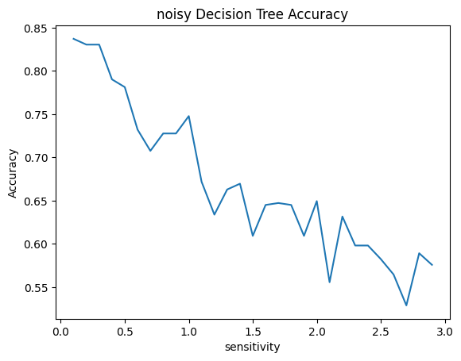

```python
scores=[0] * len(sensitivities)
for i in range(len(sensitivities)):
    DT_classifier = DecisionTreeClassifier()
    DT = Classifier(DT_classifier, DT_grid_search_params, noisy_X_trains[i], y_train)
    scores[i] = DT.calc_accuracy(noisy_X_tests[i],y_test)

plt.plot(sensitivities, scores)
plt.xlabel('sensitivity')
plt.ylabel('Accuracy')
plt.title('noisy Decision Tree Accuracy')
```

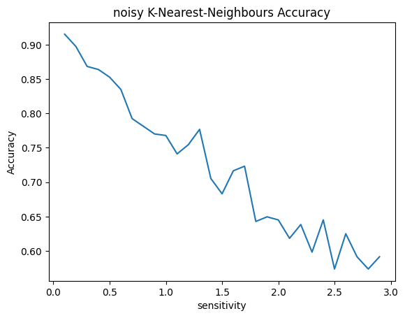

```python
scores=[0] * len(sensitivities)
for i in range(len(sensitivities)):
    KNN_classifier = KNeighborsClassifier()
    DT = Classifier(KNN_classifier, KNN_grid_search_params, noisy_X_trains[i], y_train)
    scores[i] = DT.calc_accuracy(noisy_X_tests[i],y_test)

plt.plot(sensitivities, scores)
plt.xlabel('sensitivity')
plt.ylabel('Accuracy')
plt.title('noisy K-Nearest-Neighbours Accuracy')
```

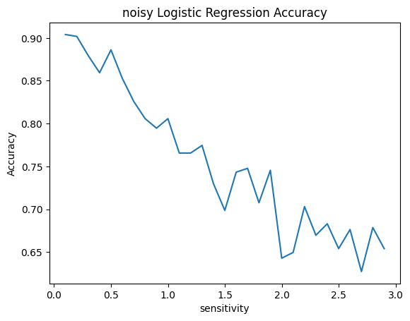

```python
scores=[0] * len(sensitivities)
for i in range(len(sensitivities)):
    LR_classifier = LogisticRegression(max_iter=500)
    LR = Classifier(LR_classifier, LR_grid_search_params, noisy_X_trains[i], y_train)
    scores[i] = LR.calc_accuracy(noisy_X_tests[i],y_test)

plt.plot(sensitivities, scores)
plt.xlabel('sensitivity')
plt.ylabel('Accuracy')
plt.title('noisy Logistic Regression Accuracy')
```

### Gradient-Boosting

Gradient boosting is a popular machine learning technique for building predictive models. It involves combining multiple weak models, typically decision trees, to create a strong ensemble model. The basic idea is to fit a sequence of simple models to the residuals of the previous model, with the objective of minimizing a loss function. This process continues until a stopping criterion is met, such as a maximum number of iterations or a minimum improvement in the loss function.

`Boosting Tree vs Decision Tree:`

- **Ensemble vs. Single Model:** Boosting tree is an ensemble learning algorithm that combines multiple weak learners (usually decision trees) into a strong learner, while decision tree is a single model that makes predictions based on a single tree-like structure.
- **Iterative vs. Non-Iterative:** Boosting tree is an iterative algorithm that adds new trees to the ensemble iteratively, with each new tree attempting to correct the errors of the previous trees, while decision tree is a non-iterative algorithm that constructs a single tree-like structure based on the input features.
- **Bias-Variance Tradeoff:** Boosting tree is designed to reduce both bias and variance, by combining multiple weak learners into a strong learner that can make accurate predictions on new, unseen data, while decision tree is prone to overfitting, especially when the tree is too deep or the number of training samples is too small.
- **Hyperparameters:** Boosting tree has several hyperparameters that can be tuned to improve its performance, such as the learning rate, the number of trees in the ensemble, the maximum depth of each tree, and the minimum number of samples required to split a node, while decision tree has fewer hyperparameters, such as the maximum depth of the tree, the minimum number of samples required to split a node, and the splitting criterion.
- **Interpretability:** Decision tree is more interpretable than boosting tree, because it produces a single tree-like structure that can be easily visualized and understood, while boosting tree produces an ensemble of trees that can be more difficult to interpret.

`XGBoost:`  
XGBoost (Extreme Gradient Boosting) is a specific implementation of gradient boosting that is designed to be efficient, scalable, and highly accurate. It uses a combination of techniques, such as parallel processing, tree pruning, and regularization, to optimize the training process and improve the performance of the model.

- `max_depth`: The maximum depth of each decision tree in the ensemble. Increasing this value can make the model more complex and potentially more accurate, but may also increase the risk of overfitting.
- `learning_rate`: The step size used to update the weights of the model during each iteration. A smaller learning rate can make the model more conservative and less prone to overfitting, but may also require more iterations to converge.
- `n_estimators`: The number of decision trees in the ensemble. Increasing this value can make the model more accurate, but may also increase the risk of overfitting and make the model slower to train.
- `subsample`: The fraction of the training data used to train each decision tree. Setting this value to less than 1.0 can make the model more robust to noise and reduce overfitting.
- `colsample_bytree`: The fraction of the features used to train each decision tree. Setting this value to less than 1.0 can make the model more robust to noise and reduce overfitting.
- `gamma`: The minimum reduction in the loss function required to make a split at a node. Increasing this value can make the model more conservative and less prone to overfitting.

```
Initial model's test accuracy:  0.946
Best model's train accuracy score: 1.000
Best model's test score: 0.944
Best hyperparameters: {'gamma': 0, 'learning_rate': 0.09, 'max_depth': 9, 'n_estimators': 200}
```

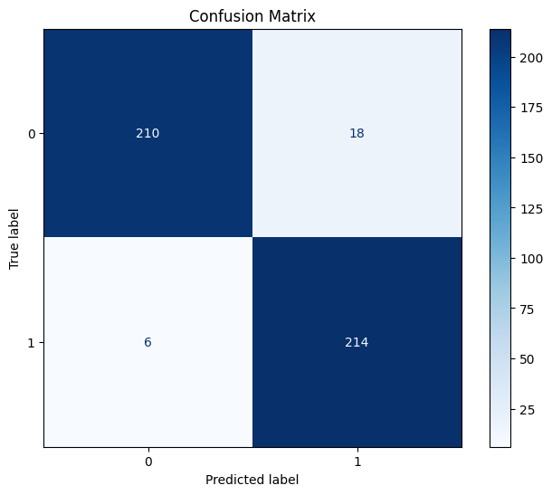

```python
XGB_grid_search_params = {
    'max_depth': range(3,11,2),
    'learning_rate': [0.01, 0.03, 0.09, 0.1],
    'n_estimators': range(20,201,30),
    'gamma': [0, 1, 10, 100]
}
XGB = Classifier(XGBClassifier(), XGB_grid_search_params, X_train, y_train)
XGB.run(X_test, y_test)
```